# README

## 📌 Description

full open source workflow for generating a geostatistics block model  
this script integrates multiple generic tools and modules in a single graphical desktop application  
the target audience is academic use by geostatistic professionals or industrial proof of concepts projects  
its not suited for production use

## 📸 Screenshot

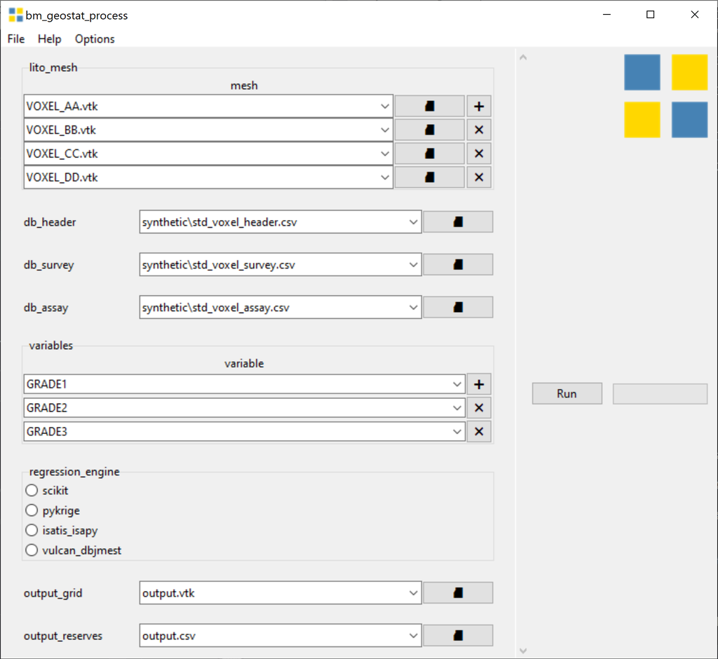

## 🧩 Implementation

The main implementation is a windows batch script that calls secondary processes for each step.  
It can be adapted to run in other platforms since the provided tools inherit the portability of Python.  
This geostatistics estimation process consists of the following steps:

1. Data and parameter input
2. Hole desurvey (runlength)
3. Sample database postprocess
4. Grid creation
5. Flag litho solids
6. Multivariate grade estimation
7. Estimation Postprocess
8. QA checks
9. Reserve Report

## 📦 Installation

In case a python distribution is not already available, the recomended distribution is [Winpython](https://winpython.github.io/) 3.11+.  
Download the installer from the link above.  
Extract into this windows special folder:  
`%APPDATA%`  
The correct path to the python executable should be similar to this example:  
`C:\Users\user\AppData\Roaming\WPy64-31131\python-3.11.3.amd64\python.exe`  
Download this entire repository as zip and extract to a valid folder.  
Windows blocks executables in protected folders (and subfolders) such as:

- Desktop
- Downloads
- Documents
- OneDrive Synced folders

Also, its not recomended to use the winpython install folder to save this script.  
So you may need to create a new valid folder directly in the C: drive. Ex.:  
`c:\scripts\geostat`

## 🎬 Run

Double click the main script on Windows Explorer:  
`bm_geostat_process.bat`  
The graphical interface should appear.  
Optionally, it can be called from the command line. A proper command line can be generated by using the menu `File ➔ Copy command line` on the graphical interface.

## 📝 Parameters

| name | optional | description |
| --- | --- | --- |
| lito_mesh | ❎ | zero or more vtk format solid meshes defining the lithology volumes |
| db_header | ❎ | header of hole database in csv format (x,y,z) |
| db_survey | ❎ | survey of hole database in csv format (azimuth, dip) |
| db_assay | ❎ | assay of hole database in csv format (from, to) |
| variables | ❎ | select which fields will be estimated as grades |
| regression_engine |  | the estimation can be adapted to use different engines |
|  | scikit | open source scikit linear regression |
|  | pykrige | open source pykrige native python krigging |
|  | isatis_isapy | proprietary native python krigging from Geovariances |
|  | vulcan_djbmest | proprietary command line krigging from Maptek |
| output_grid | ❎ | path to save the block model in vtk format |
| output_reserves | ☑️ | path to save the reserves report in csv format |
| output_heatmap | ☑️ | path to save the a heatmap chart of the result in pdf format |

## 📚 Examples

### output 3d grid

[figure not shown]

### output reserves report

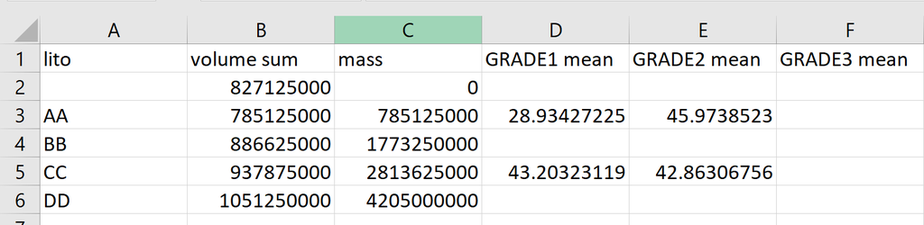

### output heatmap chart

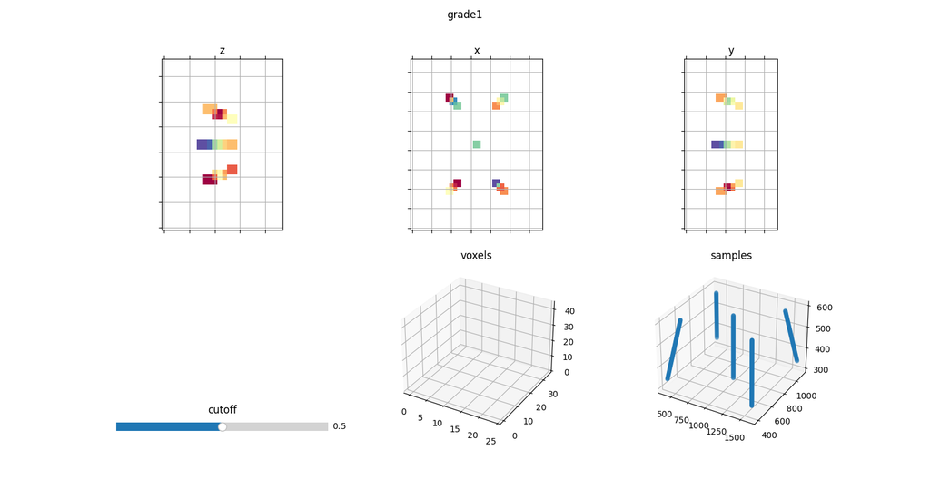

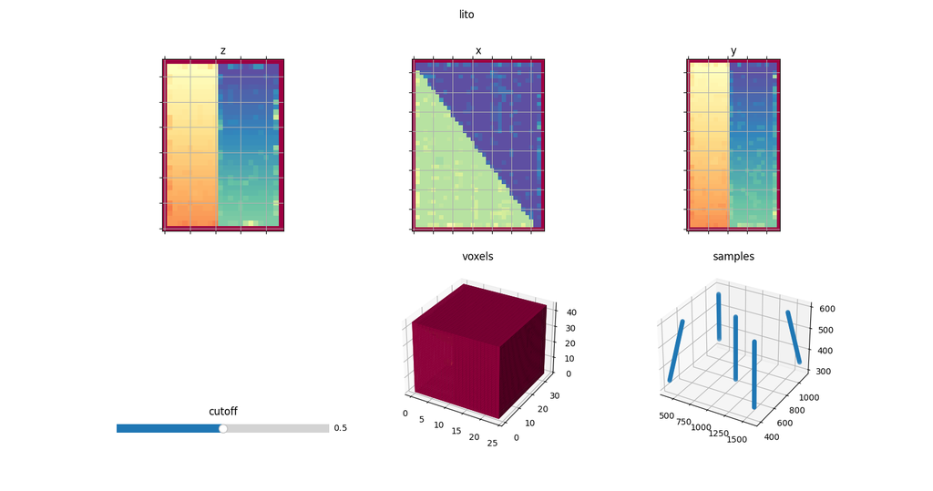

## 🙋 Support

Any question or problem contact:

- paulo.ernesto

## 💎 License

Apache 2.0  
Copyright

[figure not shown]

Vale 2023